# Práctica de Procesos Estocásticos

Rous

2/3/2022

# Simulación de procesos

## Proceso de Wiener

Este código simularemos un proceso de Wiener Generalizado y observaremos la variable que siga un comportamiento de ese tipo.

$$dW=\epsilon\sqrt{dt}$$

Donde

$$\epsilon~N(0,1)$$

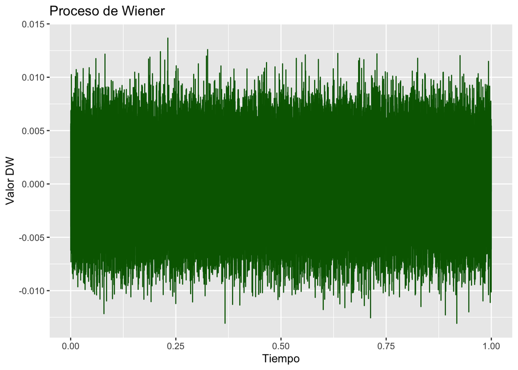

```r
datos <- tibble(t=seq(1/sim, 1, by=1/sim),dw)
ggplot(datos)+
  geom_line(aes(x=t , y=dw), color="darkgreen")+
  labs(x="Tiempo", y="Valor DW", title = "Proceso de Wiener")
```

¿Cómo sería W?

$$W_t=W_{t-1}+dw_t$$

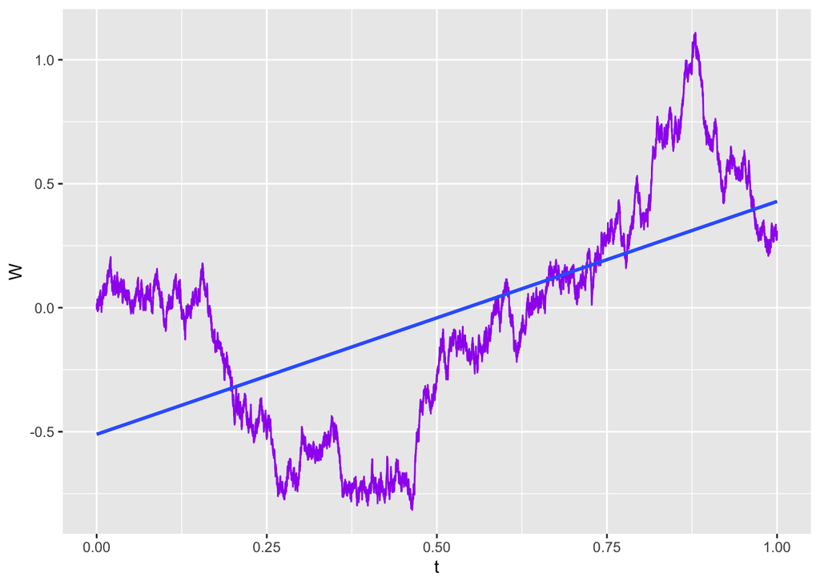

```r
W <- 0
W[1] <- 0
for (t in 2:sim) {
  W[t]=W[t-1]+dw[t]
}
datos <- mutate(datos, W=W)

ggplot(datos)+
  geom_line(aes(x=t ,y=W), color="purple")+
  geom_smooth(aes(x=t, y=W), method = "lm")
```

## Proceso de Wiener Generalizado

En este caso

$$dX=adt+bdw$$

```r
a <- 0.3
b <- 0.15
dx <- a*dt+b*dw
```

Ahora X, sería

$$X_t=X_{t-1}+dx_t$$

```r
X <- 0
X[1] <- 0
for (t in 2:sim) {
  X[t]=X[t-1]+dx[t]
}
```

Para graficarla

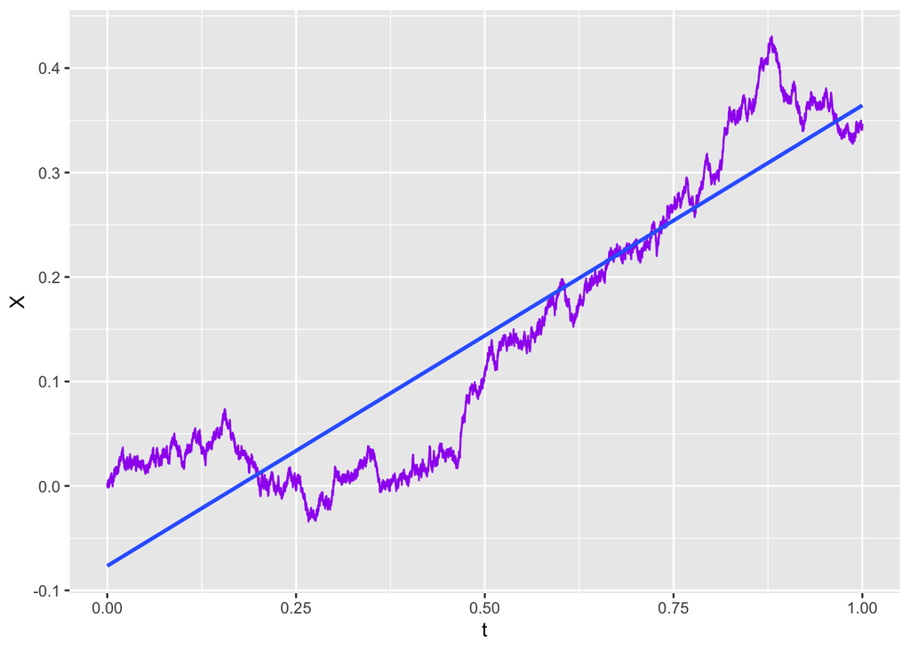

```r
datos <- mutate(datos, X=X)

ggplot(datos)+
  geom_line(aes(x=t ,y=X), color="purple")+
  geom_smooth(aes(x=t, y=X), method = "lm")
```

# Resolviendo un problema

Una determinada variable sigue un proceso de WG, con una drift rate de 2 y una tasa de varianza de 4. Ambas con unidad de tiempo semestral. Si el día de hoy la variable X toma el valor de 50.

Del desastre de la clase pasada, ya sabemos que

$$dX_a=4+2\sqrt{2}\epsilon$$

Representa el cambio en la VA dentro de un año.

```r
dxa <- 4+2*sqrt(2)*epsilon
Xa <- 50+dxa
```

En este caso Xa contiene muchos posibles valores para un solo punto en el tiempo. Antes lo que observamos era la evolución de todos los valores de X.

- ¿Cuál es el valor esperado y la varianza de X dentro de 1 año?

  ```r
  mean(Xa)
  ```

  ```
  ## [1] 54.00276
  ```

  ```r
  var(Xa)
  ```

  ```
  ## [1] 7.995735
  ```

- ¿Cuáles son las probabilidades de que el cambio en X, sea mayor a cero?

  ```r
  mean(dxa>0)
  ```

  ```
  ## [1] 0.92139
  ```

- ¿Cuáles son las probabilidades de que el cambio en X, sea menor a cero?

```r
1-mean(dxa>0)
```

```
## [1] 0.07861
```

- ¿Cuáles son las probabilidades que la variable X se ubique entre 50 y 51?

```r
mean(Xa>50&Xa<=51)
```

```
## [1] 0.06557
```